# POLS 1600: Probability: Limit Theorems and Maximum Likelihood Estimation

Updated

# Announcements

- Submitting outlines will be optional.
  - If you’d like more feedback on your projects, submit an updated html by Sunday November 10.
  - In terms of final grades, you all get that point.

# Overview

In these notes we’ll review some material we’ve already covered:

- Random variables
- Probability distributions

Take a more detailed look at concepts we’ve used in this course:

- Expectations
- Variances

And gain some insights into two limit theorems that are at the heart of statistical inference:

- The Law of Large Numbers
- The Central Limit Theorem

For the most part, we’ll leave proving these theorems to other classes. Our goal is to understand the intuition and implications of these foundational theorems for our work.

Next, we’ll take a brief tour of likelihoods and generalized linear models.

# Review

## Random Variables

A **random variable** is simply a *function* which maps outcomes in the sample space to real numbers.

### Distributions

We often talk about the **distribution** of a random variable, which can be thought of as:

$$\text{distribution} = \text{list of possible} \textbf{ values} + \text{associated} \textbf{ probabilities}$$

This is not a strict mathematical definition, but is useful for conveying the idea.

If the possible values of a random variables are *discrete* (finite or countably infinite), it is called a *discrete random variable*. If the possible values of a random variables are *continuous*, it is called a *continuous random variable*.

## Expected Value

A (probability) weighted average of the possible outcomes of a random variable, often labeled $\mu$

Discrete:

$$\mu_X=E(X)=\sum xp(x)$$

Continuous
$$\mu_X=E(X)=\int_{-\infty}^{\infty}xf(x) dx$$

# The Law of Large Numbers

## The (Weak) Law of Large Numbers

Let $X_1, X_2, \dots$ be independent and identically distributed (i.i.d.) random variables with mean $\mu$ and variance $\sigma^2$. Then for every $\epsilon>0$,

$$p(\left|\frac{X_1+\dots+X_n}{n}-\mu\right| > \epsilon) \to 0 \text{ as }n \to \infty$$

> In words: as the sample size increases, the distance of a sample mean from the population mean $\mu$ goes to 0.

Consider a **population** of size 100 (say students in an intro course), and taking **samples** that increase in size from 1 to 100.

When the sample size is small, your sample mean will vary a lot, but as it approaches 100, the sample mean converges to the population mean.

When your sample is the population you simply get the population value over and over.

## Simulating the LLN

We saw last class that the expected value of rolling a die, was 3.5.

$$E[X] = \Sigma x_ip(X=x_i) = 1/6 * (1+2+3+4+5+6)$$

In terms of the LLN, think of our sample size as the number of times we roll a die.

If we rolled the die just once and took the average of our role, we could get a 1, 2, 3, 4, 5, or 6. which would be pretty far from our expected value of 3.5

If we rolled the die two times and took an average, we could still get an value of 1 or 6 for average, but values closer to our expected value of 3.5, happen more often

```r
table(rowMeans(expand.grid(1:6, 1:6)))
```

```
##
##   1 1.5   2 2.5   3 3.5   4 4.5   5 5.5   6
##   1   2   3   4   5   6   5   4   3   2   1
```

As we increase our sample size (roll the die more times), the LLN says the chance that our sample average is far from the truth ($p(\left|\frac{X_1+\dots+X_n}{n}-\mu\right| > \epsilon)$), get’s vanishingly small.

As always, we can use R and functions to simulate this process:

```r
# Create a six-sided die
die <- 1:6

# Right a function that rolls our die
roll_fn <- function(n) {
  # save the value of each roll in a data frame called rolls
  rolls <- data.frame(rolls = sample(die, size = n, replace = TRUE))
  # summarize rolls
  df <- rolls %>%
    summarise(
    # number of rolls
      n_rolls = n(),
    # number of times 1 was rolled
      ones = sum(rolls == 1),
    # number of times 2 was rolled, etc..
      twos = sum(rolls == 2),
      threes = sum(rolls == 3),
      fours = sum(rolls == 4),
      fives = sum(rolls == 5),
      sixes = sum(rolls == 6),

      # Average of all our rolls
      average =  mean(rolls),
      # Absolute difference between averages and rolls
      abs_error = abs(3.5-average)
    )
  # Return summary df
  df
}
```

Then we could use a for-loop to simulate rolling our die once and calculating the average all the way up to rolling our die a 1000 times.

```r
# Holder
sim_df <- NULL

# Set seed
set.seed(123)

for(i in 1:1000){
  sim_df <- rbind(sim_df,
                  roll_fn(i)
  )
}
```

With only a few rolls, our average bounces around a lot

```r
head(sim_df)
```

```
##   n_rolls ones twos threes fours fives sixes  average abs_error
## 1       1    0    0      1     0     0     0 3.000000 0.5000000
## 2       2    0    0      1     0     0     1 4.500000 1.0000000
## 3       3    0    2      0     0     0     1 3.333333 0.1666667
## 4       4    0    0      1     1     1     1 4.500000 1.0000000
## 5       5    1    1      1     0     1     1 3.400000 0.1000000
## 6       6    3    0      2     1     0     0 2.166667 1.3333333
```

With a lot of rolls, our average is very close to 3.5

```r
tail(sim_df)
```

```
##      n_rolls ones twos threes fours fives sixes  average  abs_error
## 995      995  197  160    151   154   171   162 3.430151 0.06984925
## 996      996  184  164    176   149   175   148 3.412651 0.08734940
## 997      997  163  159    170   163   171   171 3.534604 0.03460381
## 998      998  162  163    142   173   185   173 3.576152 0.07615230
## 999      999  209  154    151   154   163   168 3.412412 0.08758759
## 1000    1000  181  189    147   179   146   158 3.394000 0.10600000
```

Let’s visualize see how our average changes with the number of rolls, using `ggplot()`

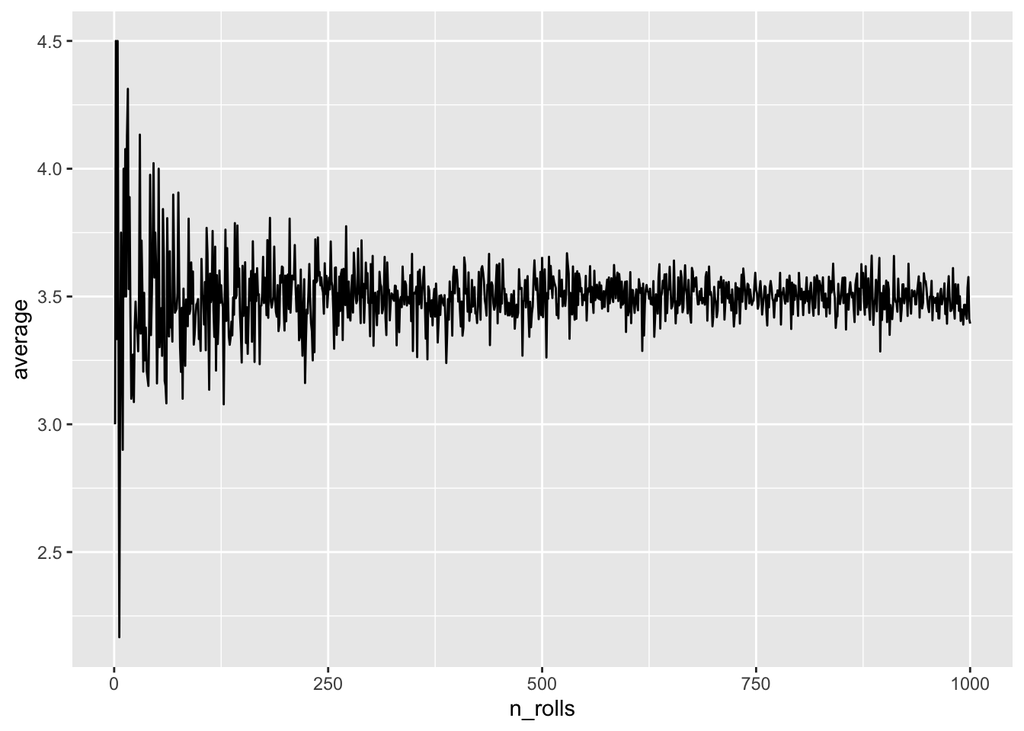

```r
p <- ggplot(sim_df, aes(n_rolls, average))+
  geom_line()
p
```

Your turn! Plot how the absolute value of the error changes as the number of rolls increases. Does it increase or decrease? How does the rate at which it goes up or down seem to change?

```r
# Write your code here:
```

## ICYI: Proving the Weak LLN

A proof of the LLN is as follows:

First define $U$ such that its a sample mean for sample of size $n$

$$U=\frac{X_1+\dots +X_n}{n}$$

Then show that the sample mean is an unbiased estimator of the population mean $\mu$

$$\begin{align*}
E[U]&=E[\frac{X_1+\dots +X_n}{n}]=\frac{1}{n}E[X_1+\dots +X_n]\\
&=\frac{n\mu}{n}=\mu
\end{align*}$$
With a variance

$$\begin{align*}
Var[U]&=Var[\frac{X_1+\dots +X_n}{n}]=\\
&=Var[\frac{X_1}{n}]\dots Var[\frac{+X_n}{n}]\\
&\frac{\sigma^2}{n^2}\dots \frac{\sigma^2}{n^2}\\
&\frac{n \sigma^2}{n^2}\\
&\frac{\sigma^2}{n}\\
\end{align*}$$

That decreases with N.

Then, by [Chebyshev’s inequality](https://en.wikipedia.org/wiki/Chebyshev%27s_inequality), a theorem specifying, for a given distribution, the maximum fraction of values that can be some distance from that distribution’s mean:

$$p(\left|U-\mu\right| > \epsilon) \leq \frac{\sigma^2}{n\epsilon^2}$$

Which $\to 0$ as $n \to \infty$

# The Central Limit Theorem

So the LLN tells us that as our sample size grows, an unbiased estimator like the sample average, will get increasingly close to the to the “true” value of the population of mean.

So if we took a bunch of samples of the same size and calculated the mean of each sample, the distribution of those sample means (the sampling distribution) would be centered around the truth (because the estimator is unbiased). If we increased the size of each sample, the width of the distribution (its variance) would decrease.

The Central Limit Theorem tells us about the shape of that distribution.

## ICYI: Standardization

Given a R.V. $X$ with mean $\mu$ and standard deviation $\sigma$, we can define a new R.V. $Z$ as the *standardization* of $X$:

$$Z=\frac{X-\mu}{\sigma}$$

Where Z has $\mu=0$ and $\sigma=1$.

Next let’s define some variables $S$ and $\bar{X}$ that are the sum and sample mean of $n$ iid draws of $X$

Let $X_1,X_2,\dots,X_n$ be independent and identically distributed r.v. with mean $\mu$ and standard deviation $\sigma$. Define $S_n$ and $\bar{X}_n$ as follows:

$$S_n= X_1,X_2,\dots,X_n= \sum_{i=1}^n X_i$$

$$\bar{X}=\frac{X_1,X_2,\dots,X_n}{n}= \frac{S_n}{n}$$

We can show that:

$$\begin{alignat*}{3}
E[S_n]&=n\mu \hspace{2em}Var[S_n]&=n\sigma^2 \hspace{2em} \sigma_S&=\sqrt{n}\sigma\\
E[\bar{X}_n]&=\mu \hspace{2em}Var[\bar{X}_n]&=\frac{\sigma^2}{n} \hspace{2em}\sigma_{\bar{X}}&=\frac{\sigma}{\sqrt{n}}\\
\end{alignat*}$$

Or that the expected value and variance of the sum is just $n$ times the population parameters (the true values for the distribution).

Since the mean is just the sum divided by the sample size, the expected value of the mean is equal to the population value (the mean is an unbiased estimator of the truth), and the variance and standard deviations of the mean are decreasing in $n$.

Further, we can define $Z$ to be a function of either $S$ or $\bar{X}$

$$Z_n=\frac{S_n-n\mu}{\sqrt{n}\sigma}=\frac{\bar{X}_n-\mu}{\sigma/\sqrt{n}}$$

Then:

## Central Limit Theorem

For a sufficiently large $n$

$$\begin{alignat*}{3}
\bar{X_n}&\approx N(\mu,\sigma^2/n) \bar{S_n}&\approx N(n\mu,n\sigma^2)
\bar{Z_n}&\approx N(0,1)
\end{alignat*}$$

- The distribution of means from almost any distribution is approximately normal (converges in distribution), but with a smaller variance ($\sigma^2/n$)
- Proof: Several ways, some using moments, but requires a little more math than is required for this course

Why is this result so important? Well lots of our questions come of the form, how does a typical value of Y vary with X. We may not know the true underlying distribution of Y, but we can often approximate the distribution of a typical value of Y ($E[Y]$) using a normal distribution.

## Simulating the CLT

For almost any distribution, the distribution of means from a sample of that distribution will converge to some Normal distribution.

The following chunks of code show how the distribution of a 1000 sample means from the following distributions:

- Normal
- Uniform
- Binomial
- $\chi^2$

Since we often don’t know the “true” distribution that generated our distribution, we may wish to be cautious in assuming that our sample size is “sufficiently large” to justify using a normal approximation for the sampling distribution of something like the mean.

Finally, the last set of simulations shows a case where the CLT does not hold. Specifically, a [Cauchy distribution](https://en.wikipedia.org/wiki/Cauchy_distribution) has undefined expected values and variances. As such the CLT theorem never “kicks in”

## Distribution of 1000 sample means from Normal Distribution as N increases

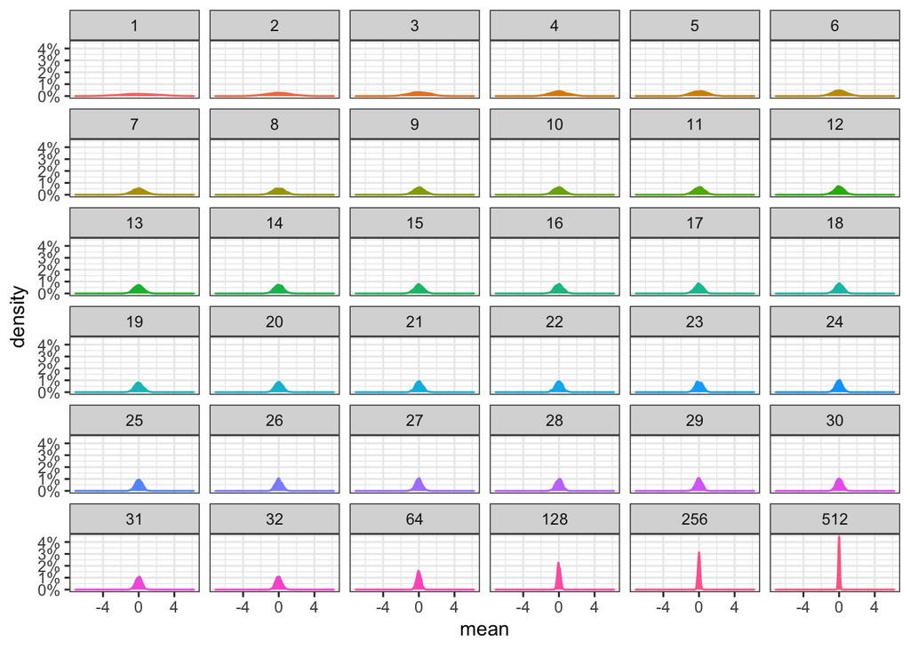

## Distribution of 1000 sample means from Discrete Uniform Distribution as N increases

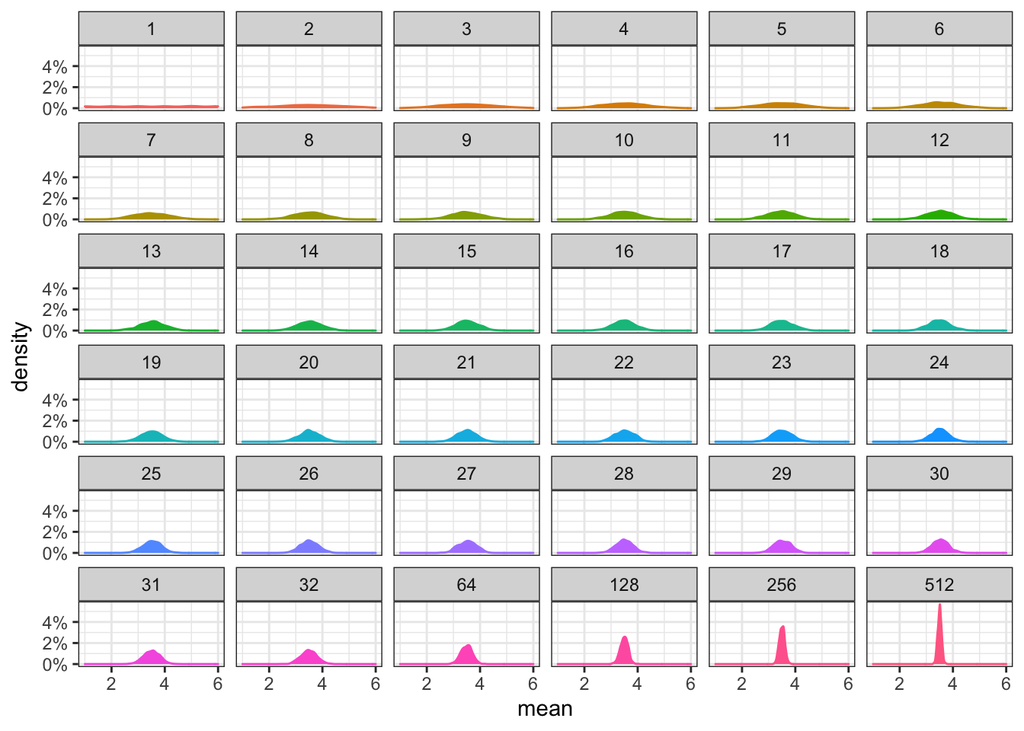

## Distribution of 1000 sample means from Binomial Distribution as N increases

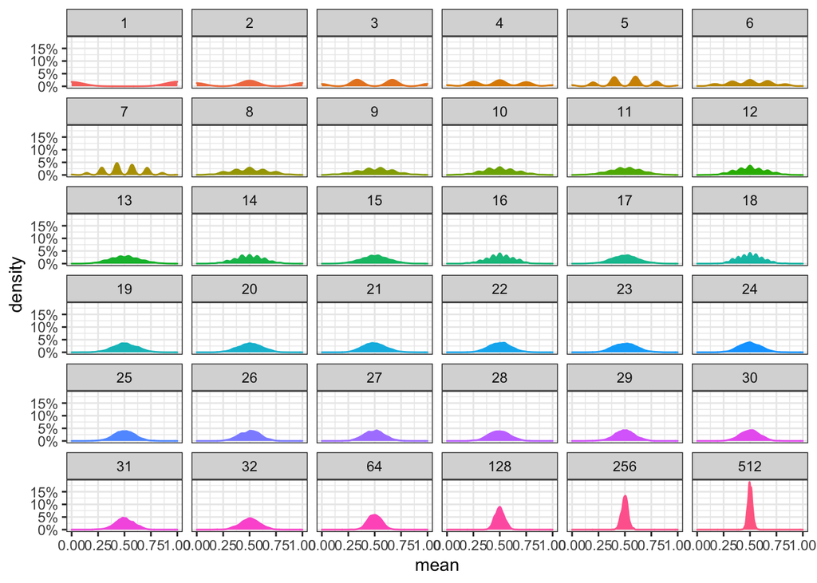

## Distribution of 1000 sample means from $\chi^2$ Distribution as N increases

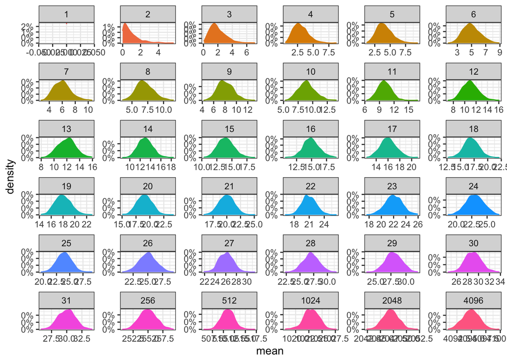

## Distribution of 1000 sample means from Cauchy Distribution as N increases

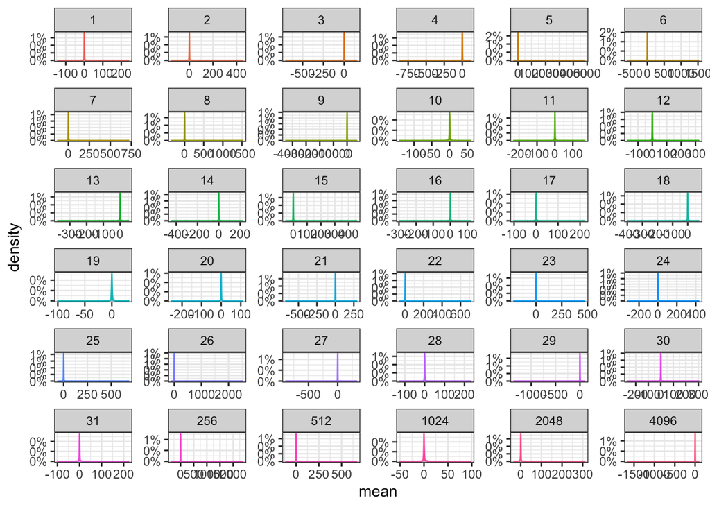

# Maximum Likelihood Estimation

The LLN and CLT lie behind many important proofs and theorems in statistics such as **maximum likelihood estimation (MLE)**

Broadly, MLE seeks to find parameters $\theta$ for model of some data generating process (i.e. a probability distribution), that are most probable (i.e. maximize the likelihood) given some data.

Formally, consider $n$ iid random variables $X_1, X_2, \ldots X_n$. We can then write their **likelihood** as

$$\mathcal{L}(\theta \mid x_1, x_2, \ldots x_n) = \prod_{i = i}^n f(x_i; \theta)$$

where $f(x_i; \theta)$ is the density (or mass) function of random variable $X_i$ evaluated at $x_i$ with parameter $\theta$.

MLE tries to find $\hat{\theta}_{MLE}$ that maximizes $\mathcal{L}(\theta \mid X)$

MLE Estimators are

- **Functionally Invariant** (The “Plug in Principle”)
  - If $\hat{\theta}$ is the MLE of $\theta$ than then the MLE of some function of $\theta$, $f(\theta)$ is $f(\hat\theta_{MLE})$
  - If we have the MLE of the variance, the square root of this will give us the MLE of the standard deviation
- **Consistent** (by the LLN)
  - $\hat\theta_{MLE}$ collapses to a spike over $\theta$ as $n \to \infty$
- **Asympotically Normal**
  - A $n \to \infty$ the sampling distribution of $\hat\theta_{MLE}$ becomes Normally distributed
  - Makes calculating quantities for inference easy
- **Asympotically Efficient**
  - As $n \to \infty$, $\hat\theta_{MLE}$ tends to be the estimator with the lowest error

A rigorous discussion of these topics is beyond the scope of this course. In class we’ll make two points:

- MLE is useful for modeling data generated from a variety of distributions
- OLS provides a linear estimate to the conditional mean function
- If the conditional mean function is linear and the errors are normally distributed, OLS is the MLE.
- What if the conditional mean function is non-linear?
- Sometimes we can transform the mean function so that it is linear, and estimate a generalized linear model (GLM) using MLE
- We need to use MLE, because unlike OLS, there typically isn’t an analytic solution. Instead we need to use calculus to find values of our estimates that maximize some likelihood function.
  - Using a GLM often produces more “reasonable” estimates, and can make more efficient use of the data, although there are many cases where a linear estimate to conditional mean function works just fine (or better)

## MLE and Generalized Linear Models

We can think some variable $y$ as having a distribution $f$ that contains both a stochastic (random) and systematic components

$$\begin{aligned}
\text{Stochastic: }&& y \sim f(\mu,\alpha)\\
\text{Systematic: }&&\mu = g(X\beta)
\end{aligned}$$

In the past we’ve described the process of modeling $y$ using a linear regression:

$$y = \beta_0 + \beta_1 x + \epsilon$$

and with multiple predictors:

$$y = X\beta + \epsilon$$

We haven’t really talked about the distribution of $\epsilon$, in part because OLS doesn’t require any distributional assumptions to be unbiased.

But if we assumed $\epsilon$ are normally distributed, with mean 0 and variance $\sigma^2$

$$\epsilon \sim f_\mathcal{N}(0,\sigma^2)$$

Then we could write our model for $y$ as follows:

$$y \sim f_{\mathcal{N}}(\mu,\sigma^2)\\
\mu = X\beta$$

Where the systematic component of why is modeled by $X\beta$ (i.e. g() is the identity function), with errors that are Normally distributed.

The $\beta$s that OLS estimates turn out to be the same values that would get by maximizing the likelihood of this function, given our data, $X$, assuming normally distributed errors.

**But what if our outcome doesn’t follow a normal distribution?**

Say for example, we have a binary outcome,that we think follows a Bernoulli distribution with $\pi$ probability of success.

We could model the *systematic* portion of this using the logit transform as our function, $g()$

$$y \sim f_{Bern}(\pi)\\
\pi = \frac{1}{1+\exp(-{X\beta})}$$

Again, we could estimate $\beta$ using the MLE to fit a logistic regression.

Or if we had a count variable, we might use a Poisson distribution:

$$y \sim f_{Pois}(\lambda)\\
\lambda = \exp(X\beta)$$

Again estimating $\beta$ using MLE.

In this class, we’ll let R handle mechanics of actually fitting these models, and instead focus on interpreting their substantive differences

## OLS vs Logistic Regression

One situation where we’d use MLE is the case of binary responses variable coded using $0$ and $1$.

In practice, these $0$ and $1$s will code for two classes such as yes/no, cat/dog, sick/healthy, etc.

How should we model this relationship?

We could use OLS to produce a linear estimate of the conditional mean function ($\text{E}[Y \mid {\bf X} = {\bf x}]$), by finding $\beta$s that minimize the sum of squared errors

Or

We could use a logistic regression, to produce a linear estimate of the “log-odds” of the conditional mean function of our binary variable by finding $\beta$s that maximize the likelihood of this function.

We’ll get more practice with this in lab.

For now, let’s focus on on a general illustration

To investigate, let’s simulate data from the following model:

$$\log\left(\frac{p({\bf x})}{1 - p({\bf x})}\right) = -2 + 3 x$$

We’ll codify this into a function:

```r
sim_logistic_data = function(sample_size = 25, beta_0 = -2, beta_1 = 3) {
  x = rnorm(n = sample_size)
  eta = beta_0 + beta_1 * x
  p = 1 / (1 + exp(-eta))
  y = rbinom(n = sample_size, size = 1, prob = p)
  data.frame(y, x)
}
```

And use it to generate some data

```r
set.seed(1)
example_data = sim_logistic_data()
head(example_data)
```

[output not shown]

After simulating a dataset, we’ll then fit both ordinary linear regression and logistic regression.

```r
# ordinary linear regression
fit_lm  = lm(y ~ x, data = example_data)
# logistic regression
fit_glm = glm(y ~ x, data = example_data, family = binomial)
```

Notice that the syntax is extremely similar. What’s changed?

- `lm()` has become `glm()`
- We’ve added `family = binomial` argument

Making predictions with an object of type `glm` is slightly different than making predictions after fitting with `lm()`. In the case of logistic regression, with `family = binomial`, we have:

| `type` | Returned |
| --- | --- |
| `"link"` [default] | $\hat{\eta}({\bf x}) = \log\left(\frac{\hat{p}({\bf x})}{1 - \hat{p}({\bf x})}\right)$ |
| `"response"` | $\hat{p}({\bf x})$ |

That is, `type = "link"` will get you the log odds, while `type = "response"` will return $P[Y = 1 \mid {\bf X} = {\bf x}]$ for each observation.

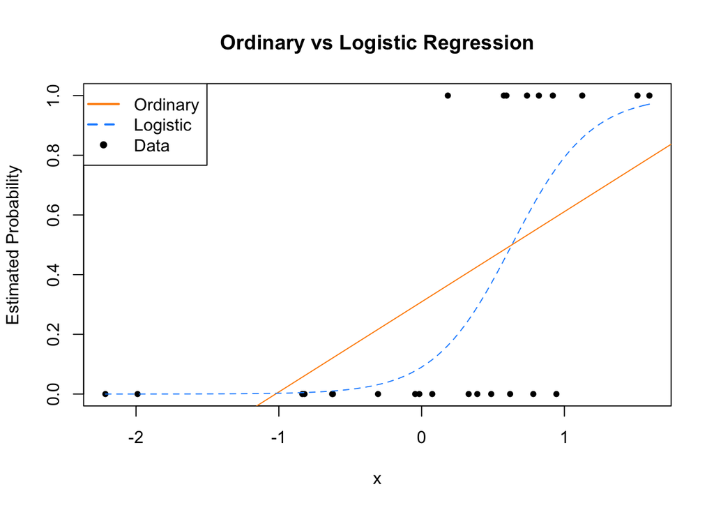

```r
plot(y ~ x, data = example_data,
     pch = 20, ylab = "Estimated Probability",
     main = "Ordinary vs Logistic Regression")
abline(fit_lm, col = "darkorange")
curve(predict(fit_glm, data.frame(x), type = "response"),
      add = TRUE, col = "dodgerblue", lty = 2)
legend("topleft", c("Ordinary", "Logistic", "Data"), lty = c(1, 2, 0),
       pch = c(NA, NA, 20), lwd = 2, col = c("darkorange", "dodgerblue", "black"))
```

Since we only have a single predictor variable, we are able to graphically show this situation. First, note that the data, is plotted using black dots. The response `y` only takes values `0` and `1`.

Next, we need to discuss the two added lines to the plot. The first, the solid orange line, is the fitted ordinary linear regression. The dashed blue curve is the estimated logistic regression.

It is helpful to realize that we are not plotting an estimate of $Y$ for either. (Sometimes it might seem that way with ordinary linear regression, but that isn’t what is happening.)

For both, we are plotting $\hat{\text{E}}[Y \mid {\bf X} = {\bf x}]$, the estimated mean, which for a binary response happens to be an estimate of $P[Y = 1 \mid {\bf X} = {\bf x}]$.

We immediately see why ordinary linear regression is not a good idea. While it is estimating the mean, we see that it produces estimates that are less than 0! (And in other situations could produce estimates greater than 1!)

If the mean is a probability, we don’t want probabilities less than 0 or greater than 1.

Enter logistic regression. Since the output of the inverse logit function is restricted to be between 0 and 1, our estimates make much more sense as probabilities. Let’s look at our estimated coefficients. (With a lot of rounding, for simplicity.)

```r
round(coef(fit_glm), 1)
```

[output not shown]

Our estimated model is then:

$$\log\left(\frac{\hat{p}({\bf x})}{1 - \hat{p}({\bf x})}\right) = -2.3 + 3.7 x$$

Because we’re not directly estimating the mean, but instead a function of the mean, we need to be careful with our interpretation of $\hat{\beta}_1 = 3.7$.

This means that, for a one unit increase in $x$, the log odds change (in this case increase) by $3.7$. Also, since $\hat{\beta}_1$ is positive, as we increase $x$ we also increase $p({\bf x})$. To see how much, we have to consider the inverse logistic function.

For example, we have:

$$\hat{P}[Y = 1 \mid X = -0.5] = \frac{e^{-2.3 + 3.7 \cdot (-0.5)}}{1 + e^{-2.3 + 3.7 \cdot (-0.5)}} \approx 0.016$$

$$\hat{P}[Y = 1 \mid X = 0] = \frac{e^{-2.3 + 3.7 \cdot (0)}}{1 + e^{-2.3 + 3.7 \cdot (0)}} \approx 0.09112296$$

$$\hat{P}[Y = 1 \mid X = 1] = \frac{e^{-2.3 + 3.7 \cdot (1)}}{1 + e^{-2.3 + 3.7 \cdot (1)}} \approx 0.8021839$$